# [Accuracy vs Area Size] UWB Experiment Summery

### Ground Truth vs UWB Reading

The comparison between the ground truth measurement and the UWB reading is shown in this Figure 3.

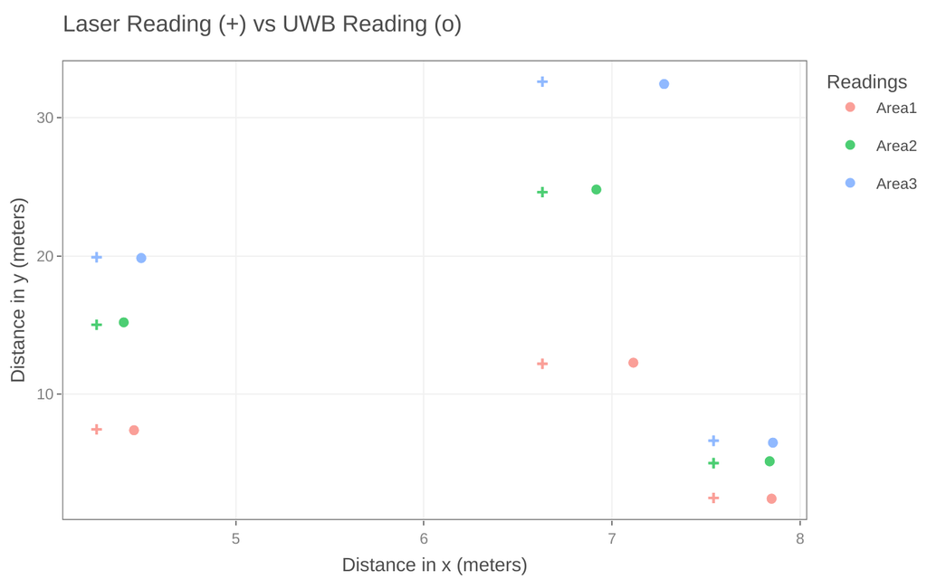

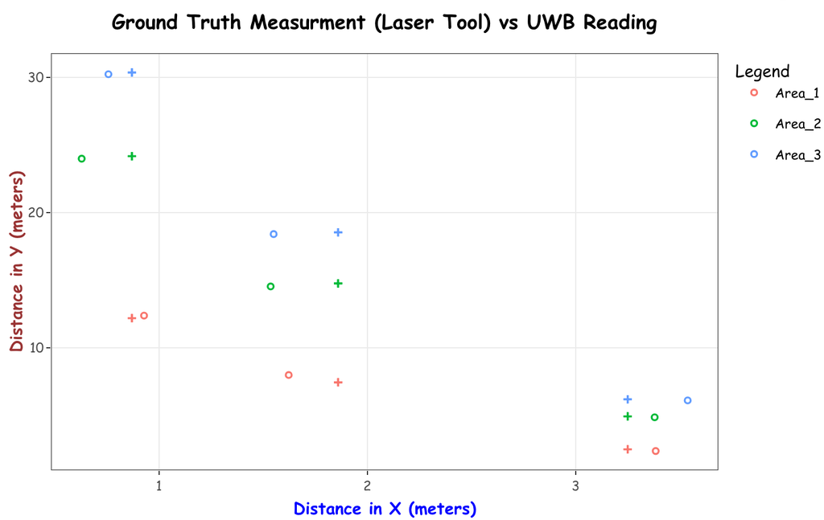

Comparison between the ground truth measurement and the UWB reading Exp1 vs Exp2

### Comparison between the Total XY RMS Error for the 3 Areas

Figure 4 depicts an overall comparison of how the total RMSE of the observations differs across the three areas. According to those Figures, the lowest RMSE for Exp1 could be found in Area 2, whereas the lowest RMSE for Exp2 could be found in Area 3. Thus, the accuracy obtained from Exp2 is more than that obtained from Exp1 since Area 3 is substantially larger than Area 2, indicating that the Exp2 configuration is significantly superior to that of the Exp1.

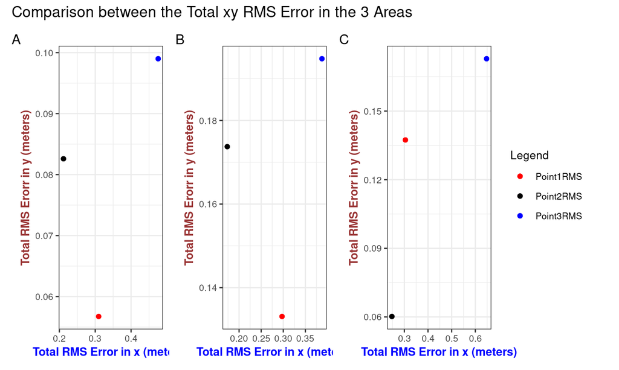

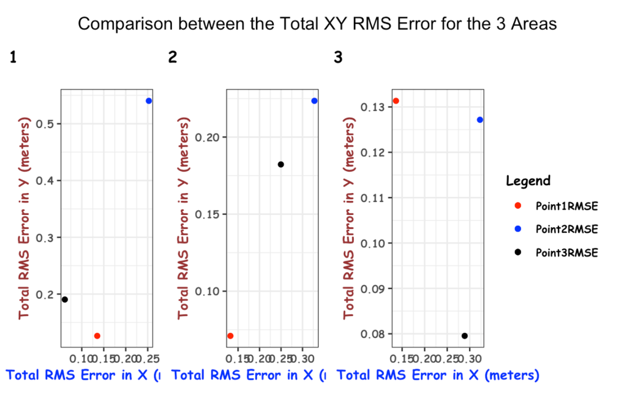

Comparison between the Total RMSE in the 3 Areas Exp1 vs Exp2

### Position Dilution of Precision & Conclusion

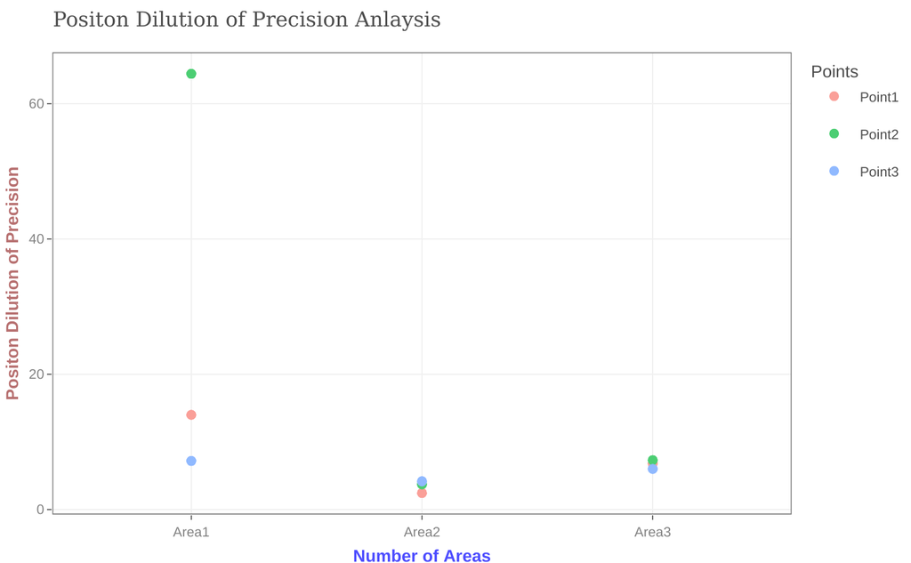

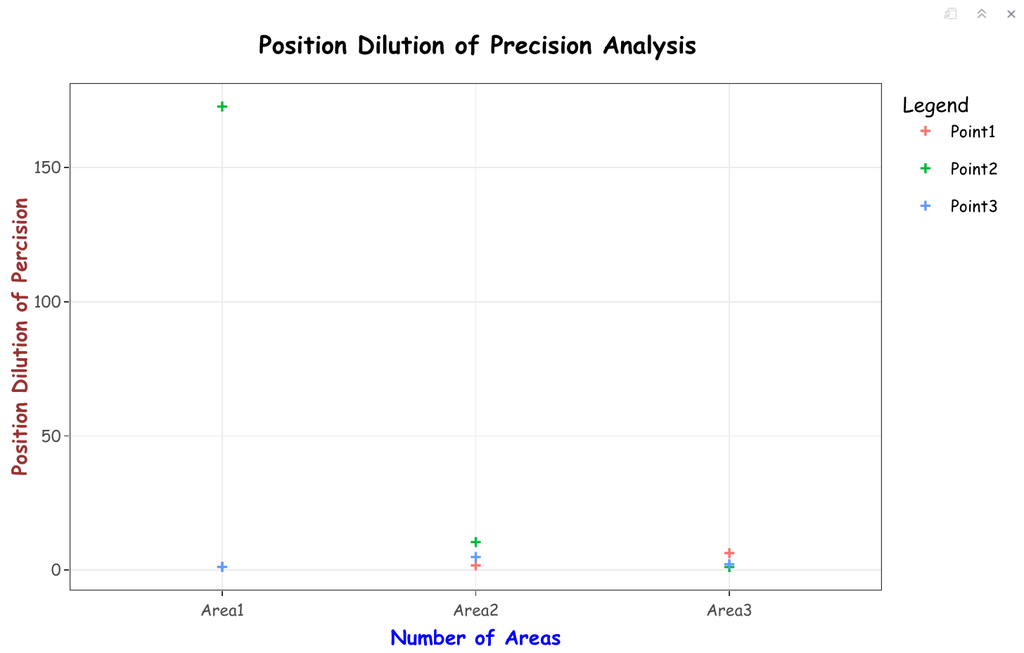

Position Dilution of Precision Exp1 vs Exp2

### Summery of the both the RMSE FOR Exp1 and Exp2

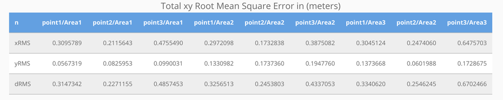

Total Root Mean Square Error Exp1

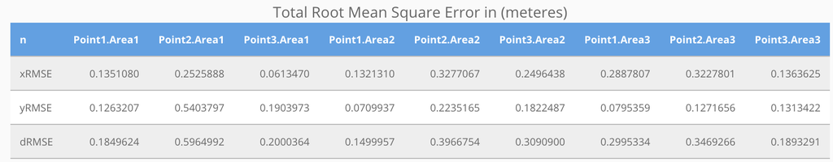

Total Root Mean Square Error Exp2